[Antonio Schettino](https://www.researchgate.net/profile/Antonio_Schettino2)

2017-04-24

Analysis of behavioral data. It is now done on averaged data, but the final dataset will have trial information.

```r
data.behav <- read.csv(here::here("behavior/pilot/pilot_behavioral_data.csv"), header = TRUE) # load data

data.behav <- within(data.behav, Size <- relevel(Size, ref = "Large")) # reference: large size
data.behav <- within(data.behav, Cont <- relevel(Cont, ref = "High")) # reference: high contrast
```

The data we will use in this demo come from a pilot experiment (N = 3).

We will calculate and compare the Bayes Factor of different linear mixed-effects models. The random factor is participants, and its variance is set as nuisance.

We will compare (against the null model) the following models:

1. main effect of size
2. main effect of contrast
3. main effects of size and contrast
4. interactive effects of size and contrast

We will then compare the best competing models to understand which one should be preferred overall.

# *ACCURACY*

```r
# summarize data
summary.data.Acc <-
  summarySEwithin(
    data.behav,
    "Accuracy",
    withinvars = c("Cont", "Size"),
    idvar = "Participant"
  )

kable(summary.data.Acc)
```

| Cont | Size | N | Accuracy | sd | se | ci |
| --- | --- | --- | --- | --- | --- | --- |
| High | Large | 3 | 0.983 | 0.017 | 0.010 | 0.041 |
| High | Small | 3 | 0.967 | 0.076 | 0.044 | 0.190 |
| Low | Large | 3 | 0.983 | 0.017 | 0.010 | 0.041 |
| Low | Small | 3 | 0.883 | 0.101 | 0.059 | 0.252 |

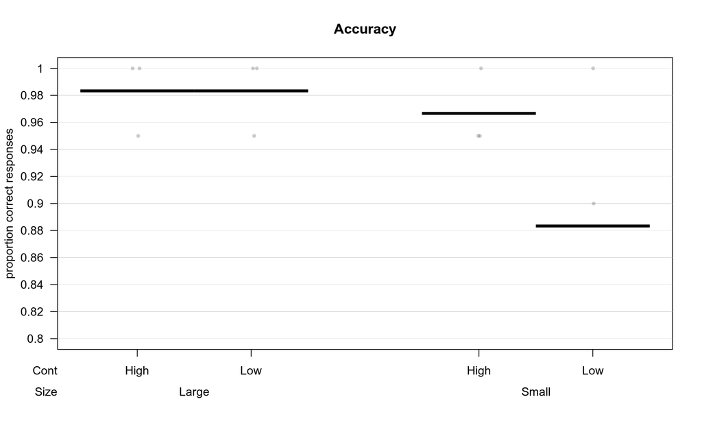

```r
# accuracy graph
pirateplot(
  formula = Accuracy ~ Cont + Size, # dependent~independent variables
  data = data.behav, # data frame
  main = "Accuracy", # main title
  xlim = NULL, # x-axis: limits
  xlab = "", # x-axis: label
  ylim = c(.8, 1), # y-axis: limits
  ylab = "proportion correct responses", # y-axis: label
  inf.method = "hdi", # type of inference: 95% Bayesian Highest Density Interval (HDI)
  hdi.iter = 5000, # number of iterations for 95% HDI
  cap.beans = TRUE, # max and min values of bean densities are capped at the limits found in the data
  pal = "xmen" # color palette [see piratepal(palette="all")]
)
```

```r
niter <- 10000 # number of MonteCarlo iterations
scaling.factor <- c(.5, sqrt(2) / 2, 1) # scaling factors of JZS prior: narrow, medium, wide)

compare.Acc.BF <- matrix(NA, 4, length(scaling.factor)) # preallocate matrix with all BF10
compare.Acc.perc.err <- matrix(NA, 4, length(scaling.factor)) # preallocate matrix with all % errors

for (k in 1:length(scaling.factor)) { # loop through scaling factors

  ### main effect of size
  Acc.size.BF <-
    lmBF(
      Accuracy ~ Size,
      data.behav,
      whichRandom = "Participant",
      rscaleFixed = scaling.factor[k],
      rscaleRandom = "nuisance",
      rscaleCont = "medium",
      iterations = niter,
      posterior = FALSE
    )

  ### main effect of contrast
  Acc.cont.BF <- lmBF(
    Accuracy ~ Cont,
    data.behav,
    whichRandom = "Participant",
    rscaleFixed = scaling.factor[k],
    rscaleRandom = "nuisance",
    rscaleCont = "medium",
    iterations = niter,
    posterior = FALSE
  )

  ### main effects of size and contrast
  Acc.sizepluscont.BF <-
    lmBF(Accuracy ~ Size + Cont,
      data.behav,
      whichRandom = "Participant",
      rscaleFixed = scaling.factor[k],
      rscaleRandom = "nuisance",
      rscaleCont = "medium",
      iterations = niter,
      posterior = FALSE
    )

  ### full model: main effects of size and contrast + their interaction
  Acc.full.BF <-
    lmBF(Accuracy ~ Size * Cont,
      data.behav,
      whichRandom = "Participant",
      rscaleFixed = scaling.factor[k],
      rscaleRandom = "nuisance",
      rscaleCont = "medium",
      iterations = niter,
      posterior = FALSE
    )

  ### model comparison
  # BFs
  compare.Acc.BF[, k] <-
    c(
      exp(1)^Acc.size.BF@bayesFactor$bf[1],
      exp(1)^Acc.cont.BF@bayesFactor$bf[1],
      exp(1)^Acc.sizepluscont.BF@bayesFactor$bf[1],
      exp(1)^Acc.full.BF@bayesFactor$bf[1]
    )

  # percentage of error
  compare.Acc.perc.err[, k] <-
    c(
      Acc.size.BF@bayesFactor$error[1] * 100,
      Acc.cont.BF@bayesFactor$error[1] * 100,
      Acc.sizepluscont.BF@bayesFactor$error[1] * 100,
      Acc.full.BF@bayesFactor$error[1] * 100
    )
}

# summary
compare.Acc <-
  data.frame(
    "model" = c("size", "contr", "size + cont", "full"),
    "nar" = round(compare.Acc.BF[, 1], digits = 3), "nar.p.err" = round(compare.Acc.perc.err[, 1], digits = 3),
    "med" = round(compare.Acc.BF[, 2], digits = 3), "med.p.err" = round(compare.Acc.perc.err[, 2], digits = 3),
    "wid" = round(compare.Acc.BF[, 3], digits = 3), "wid.p.err" = round(compare.Acc.perc.err[, 3], digits = 3)
  )

compare.Acc <- compare.Acc[order(compare.Acc$med, decreasing = TRUE), ] # sort according to medium scaling factor (in descending order)

kable(compare.Acc)
```

| model | nar | nar.p.err | med | med.p.err | wid | wid.p.err |
| --- | --- | --- | --- | --- | --- | --- |
| size | 0.894 | 0.016 | 0.800 | 0.00 | 0.681 | 0.00 |
| contr | 0.639 | 0.001 | 0.540 | 0.00 | 0.437 | 0.00 |
| size + cont | 0.595 | 0.609 | 0.460 | 0.72 | 0.314 | 2.25 |
| full | 0.466 | 0.736 | 0.299 | 1.88 | 0.192 | 1.04 |

When using a JZS prior with scaling factor r=0.707 placed on standardized effect sizes, the model null ought to be preferred.  
The best model (null) explains the observed data 1.25 times better than the second best model (size).

# *RTs*

```r
# summarize data
summary.data.RT <-
  summarySEwithin(data.behav,
    "RT",
    withinvars = c("Cont", "Size"),
    idvar = "Participant"
  )

kable(summary.data.RT)
```

| Cont | Size | N | RT | sd | se | ci |
| --- | --- | --- | --- | --- | --- | --- |
| High | Large | 3 | 563 | 9.57 | 5.53 | 23.8 |
| High | Small | 3 | 580 | 16.86 | 9.73 | 41.9 |
| Low | Large | 3 | 604 | 4.97 | 2.87 | 12.3 |
| Low | Small | 3 | 672 | 2.46 | 1.42 | 6.1 |

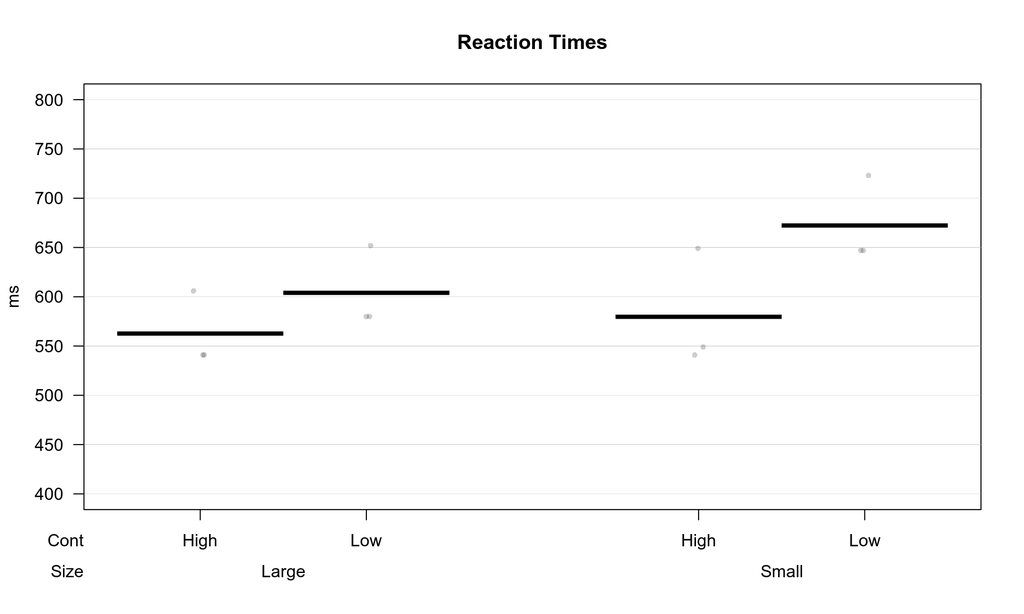

```r
# RT graph
pirateplot(
  formula = RT ~ Cont + Size, # dependent~independent variables
  data = data.behav, # data frame
  main = "Reaction Times", # main title
  xlim = NULL, # x-axis: limits
  xlab = "", # x-axis: label
  ylim = c(400, 800), # y-axis: limits
  ylab = "ms", # y-axis: label
  inf.method = "hdi", # type of inference: 95% Bayesian Highest Density Interval (HDI)
  hdi.iter = 5000, # number of iterations for 95% HDI
  cap.beans = TRUE, # max and min values of bean densities are capped at the limits found in the data
  pal = "xmen" # color palette [see piratepal(palette="all")]
)
```

```r
niter <- 10000 # number of MonteCarlo iterations
scaling.factor <- c(.5, sqrt(2) / 2, 1) # scaling factors of JZS prior: narrow, medium, wide)

compare.RT.BF <- matrix(NA, 4, length(scaling.factor)) # preallocate matrix with all BF10
compare.RT.perc.err <- matrix(NA, 4, length(scaling.factor)) # preallocate matrix with all % errors

for (k in 1:length(scaling.factor)) { # loop through scaling factors

  ### main effect of size
  RT.size.BF <-
    lmBF(
      RT ~ Size,
      data.behav,
      whichRandom = "Participant",
      rscaleFixed = scaling.factor[k],
      rscaleRandom = "nuisance",
      rscaleCont = "medium",
      iterations = niter,
      posterior = FALSE
    )

  ### main effect of contrast
  RT.cont.BF <-
    lmBF(RT ~ Cont,
      data.behav,
      whichRandom = "Participant",
      rscaleFixed = scaling.factor[k],
      rscaleRandom = "nuisance",
      rscaleCont = "medium",
      iterations = niter,
      posterior = FALSE
    )

  ### main effects of size and contrast
  RT.sizepluscont.BF <-
    lmBF(
      RT ~ Size + Cont,
      data.behav,
      whichRandom = "Participant",
      rscaleFixed = scaling.factor[k],
      rscaleRandom = "nuisance",
      rscaleCont = "medium",
      iterations = niter,
      posterior = FALSE
    )

  ### full model: main effects of size and contrast + their interaction
  RT.full.BF <-
    lmBF(
      RT ~ Size * Cont,
      data.behav,
      whichRandom = "Participant",
      rscaleFixed = scaling.factor[k],
      rscaleRandom = "nuisance",
      rscaleCont = "medium",
      iterations = niter,
      posterior = FALSE
    )

  ### model comparison
  # BFs
  compare.RT.BF[, k] <-
    c(
      exp(1)^RT.size.BF@bayesFactor$bf[1],
      exp(1)^RT.cont.BF@bayesFactor$bf[1],
      exp(1)^RT.sizepluscont.BF@bayesFactor$bf[1],
      exp(1)^RT.full.BF@bayesFactor$bf[1]
    )

  # percentage of error
  compare.RT.perc.err[, k] <-
    c(
      RT.size.BF@bayesFactor$error[1] * 100,
      RT.cont.BF@bayesFactor$error[1] * 100,
      RT.sizepluscont.BF@bayesFactor$error[1] * 100,
      RT.full.BF@bayesFactor$error[1] * 100
    )
}

# summary
compare.RT <-
  data.frame(
    "model" = c("size", "contr", "size + cont", "full"),
    "nar" = round(compare.RT.BF[, 1], digits = 3), "nar.p.err" = round(compare.RT.perc.err[, 1], digits = 3),
    "med" = round(compare.RT.BF[, 2], digits = 3), "med.p.err" = round(compare.RT.perc.err[, 2], digits = 3),
    "wid" = round(compare.RT.BF[, 3], digits = 3), "wid.p.err" = round(compare.RT.perc.err[, 3], digits = 3)
  )

compare.RT <- compare.RT[order(compare.RT$med, decreasing = TRUE), ] # sort according to medium scaling factor (in descending order)

kable(compare.RT)
```

|  | model | nar | nar.p.err | med | med.p.err | wid | wid.p.err |
| --- | --- | --- | --- | --- | --- | --- | --- |
| 2 | contr | 2.026 | 0.008 | 2.036 | 0.000 | 1.929 | 0.000 |
| 3 | size + cont | 1.919 | 0.529 | 1.761 | 1.236 | 1.474 | 1.332 |
| 4 | full | 1.417 | 3.974 | 1.134 | 0.789 | 0.822 | 0.926 |
| 1 | size | 0.776 | 0.006 | 0.678 | 0.000 | 0.566 | 0.000 |

When using a JZS prior with scaling factor r=0.707 placed on standardized effect sizes, the model contr ought to be preferred.  
The best model (contr) explains the observed data 1.156 times better than the second best model (size + cont).